# Pollster Analyzer

Haley Reed

5/29/2020

This file uses data from the FiveThirtyEight repository to isolate an individual pollster and their most recent polls at the time of every election in the dataset for the indicated years.

```r
#Establish which pollster you wish to analyze:
pollsterOfChoice="Mitchell Research & Communications"
#Establish which years you wish to use data from (between 1998 and 2020):
earlyYear=1998
lateYear=2020
```

This file will analyze data from Mitchell Research & Communications between the years of 1998 and 2020. This particular subset of data is shown in the table below:

| race_id | poll_id | question_id | year | race | location | type_simple | type_detail | pollster | pollster_rating_id | polldate | samplesize | cand1_name | cand1_party | cand1_pct | cand2_name | cand2_party | cand2_pct | cand3_pct | margin_poll | electiondate | cand1_actual | cand2_actual | margin_actual | error | bias | rightcall | comment | partisan |
| --- | --- | --- | --- | --- | --- | --- | --- | --- | --- | --- | --- | --- | --- | --- | --- | --- | --- | --- | --- | --- | --- | --- | --- | --- | --- | --- | --- | --- |
| 2 | 34317 | 42160 | 2014 | 2014_Sen-G_MI | MI | Sen-G | Sen-G | Mitchell Research & Communications | 213 | 2014-11-02 | 1224 | Gary C. Peters | DEM | 52.0 | Terri Lynn Land | REP | 40.0 | NA | 12.0 | 2014-11-04 | 54.61 | 41.33 | 13.29 | 1.29 | -1.29 | 1 |  |  |
| 106 | 56815 | 91569 | 2018 | 2018_Sen-G_MI | MI | Sen-G | Sen-G | Mitchell Research & Communications | 213 | 2018-11-05 | 827 | Debbie Stabenow | DEM | 49.0 | John James | REP | 46.0 | NA | 3.0 | 2018-11-06 | 52.26 | 45.76 | 6.51 | 3.51 | -3.51 | 1 |  |  |
| 148 | 56815 | 91568 | 2018 | 2018_Gov-G_MI | MI | Gov-G | Gov-G | Mitchell Research & Communications | 213 | 2018-11-05 | 827 | Gretchen E. Whitmer | DEM | 48.4 | Bill Schuette | REP | 40.6 | NA | 7.8 | 2018-11-06 | 53.31 | 43.75 | 9.57 | 1.77 | -1.77 | 1 |  |  |
| 624 | 48859 | 76463 | 2016 | 2016_Pres-G_MI | MI | Pres-G | Pres-G | Mitchell Research & Communications | 213 | 2016-11-06 | 1011 | Hillary Rodham Clinton | DEM | 49.0 | Donald Trump | REP | 43.0 | NA | 6.0 | 2016-11-08 | 47.03 | 47.25 | -0.22 | 6.22 | 6.22 | 0 | average of multiple versions or turnout models listed in poll |  |
| 675 | 30795 | 37150 | 2012 | 2012_Pres-G_MI | MI | Pres-G | Pres-G | Mitchell Research & Communications | 213 | 2012-11-04 | 1305 | Barack Obama | DEM | 51.0 | Mitt Romney | REP | 46.0 | NA | 5.0 | 2012-11-06 | 54.04 | 44.58 | 9.47 | 4.47 | -4.47 | 1 |  |  |
| 726 | 16395 | 21292 | 2008 | 2008_Pres-G_MI | MI | Pres-G | Pres-G | Mitchell Research & Communications | 213 | 2008-11-03 | 400 | Barack Obama | DEM | 54.0 | John McCain | REP | 38.0 | NA | 16.0 | 2008-11-04 | 57.33 | 40.89 | 16.44 | 0.44 | -0.44 | 1 |  |  |

The plot and summary statistics for margin of error for Mitchell Research & Communications between the years of 1998 and 2020 is shown below.

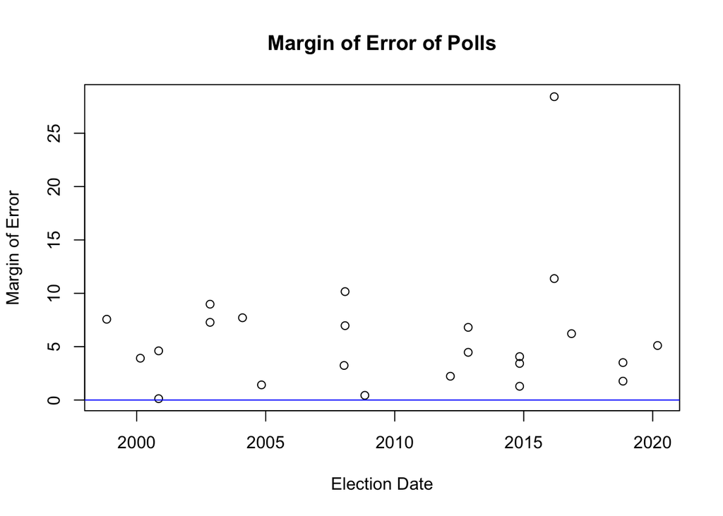

```
##    Min. 1st Qu.  Median    Mean 3rd Qu.    Max.
##   0.130   2.987   4.540   5.881   7.353  28.420
```

The plot and summary statistics for bias towards Republican candidates is shown below:

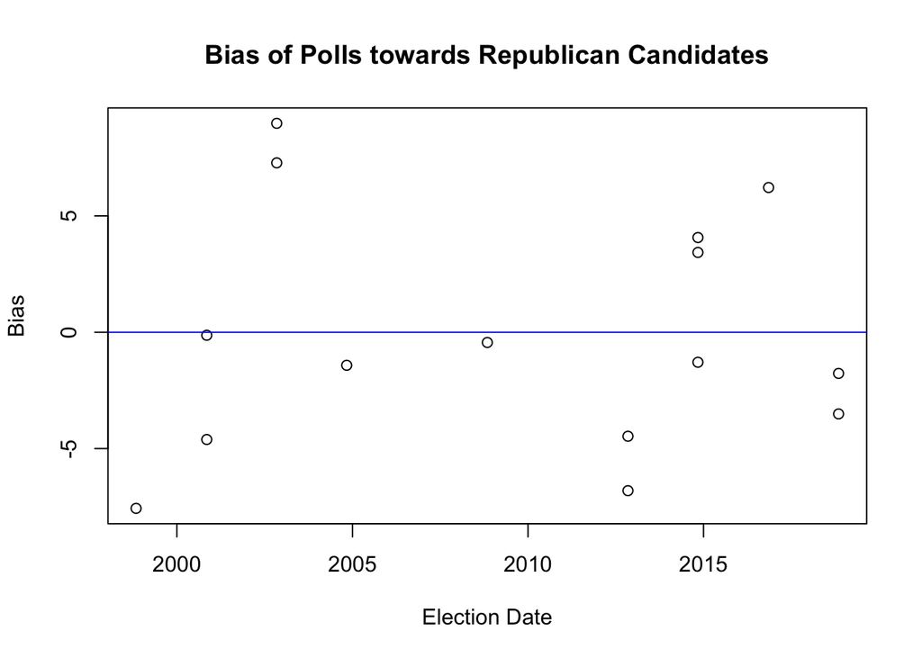

```
##    Min. 1st Qu.  Median    Mean 3rd Qu.    Max.
##  -7.570  -3.990  -1.290  -0.136   3.750   8.980
```

The density plot for the bias that Mitchell Research & Communications shows for republican candidates between the years 1998 and 2020 is shown below.

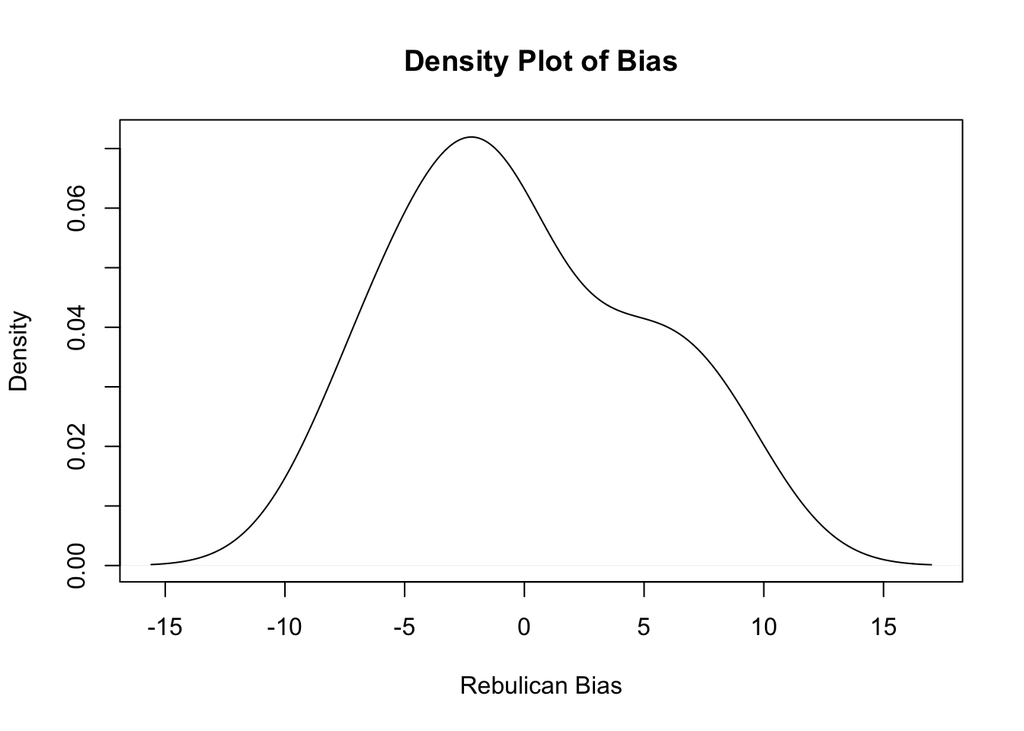

Additionally, Mitchell Research & Communications correctly predicted 81.25% of races in their last poll for every election polled from 1998 to 2020.

### All Polls

After exploring the data with only the most recent polls before every election, we can compare these findings to data that includes all polls. What is the difference between their error? Their bias? Their predictive power?

The plot and summary statistics for margin of error from all polls conducted by Mitchell Research & Communications between 1998 and 2020 is shown below.

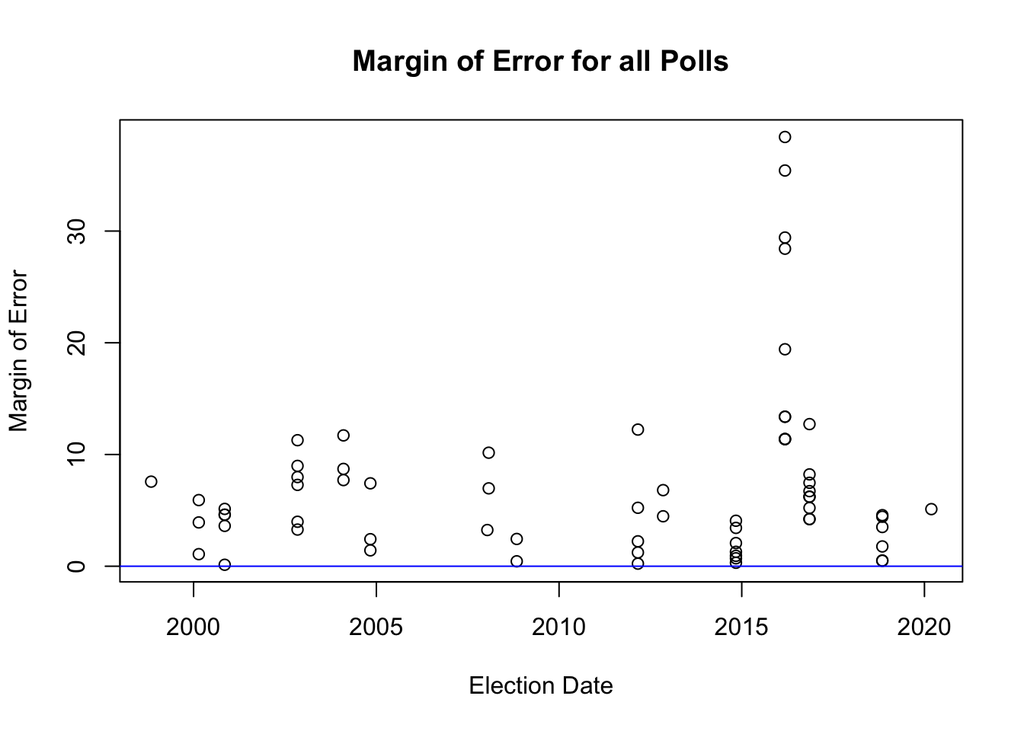

```
##    Min. 1st Qu.  Median    Mean 3rd Qu.    Max.
##   0.130   2.640   5.120   7.286   8.588  38.420
```

The plot and summary statistics for bias towards republican candidates for all polls conducted by Mitchell Research & Communications between 1998 and 2020 is shown below.

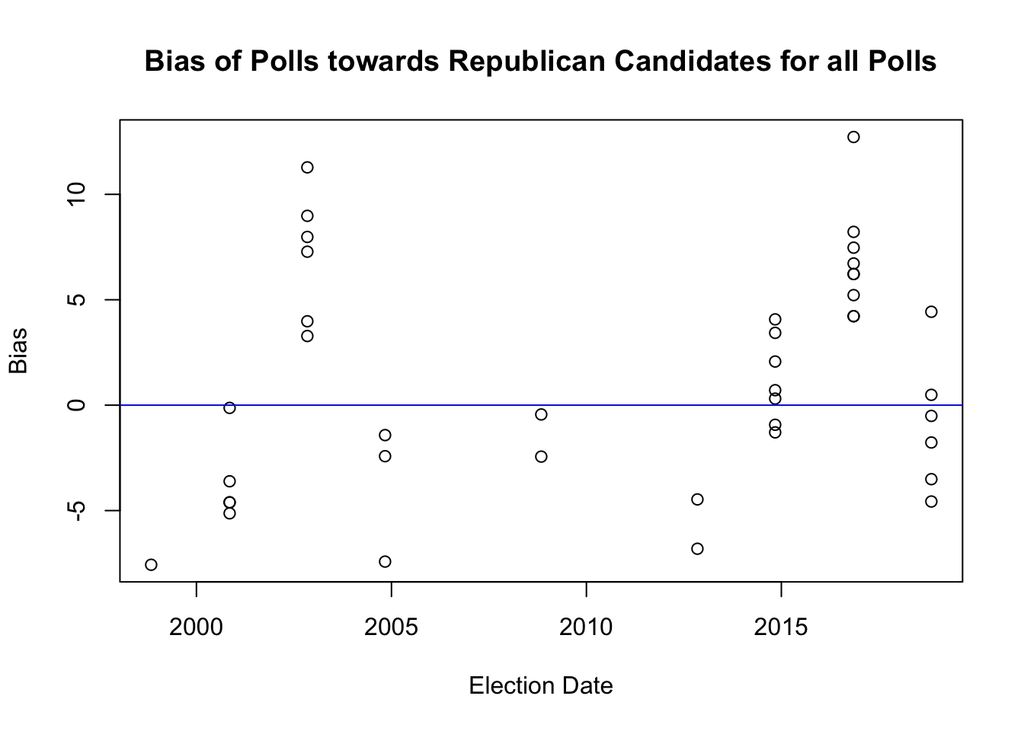

```
##    Min. 1st Qu.  Median    Mean 3rd Qu.    Max.
##  -7.570  -2.440   0.490   1.362   5.220  12.720
```

The mean bias for every year is displayed in the table and graph below.

| Year | Bias |
| --- | --- |
| 1998 | -7.5700000 |
| 2000 | -3.6180000 |
| 2002 | 7.1300000 |
| 2004 | -3.7533333 |
| 2008 | -1.4400000 |
| 2012 | -5.6400000 |
| 2014 | 1.1957143 |
| 2016 | 6.8033333 |
| 2018 | -0.9066667 |

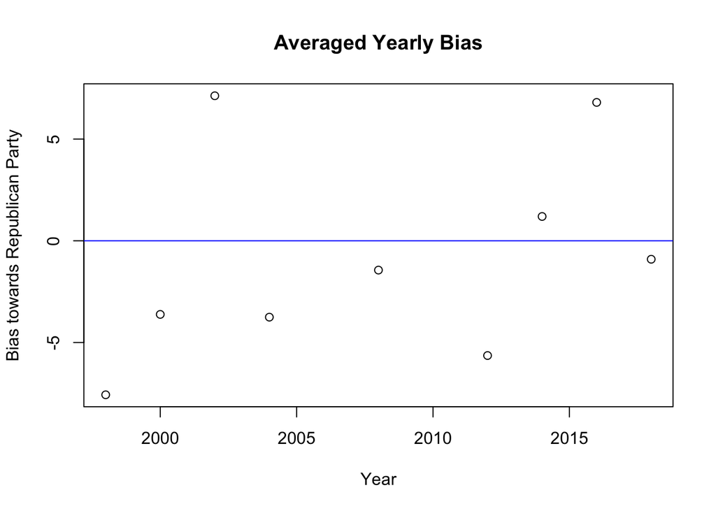

For Mitchell Research & Communications the standard deviation of averaged yearly biases is 5.1354329.

Additionally, using just the most recent poll from each election predicted more races correctly than using all polls. Mitchell Research & Communications correctly predicted 66.6666667% of races using all polls from every election polled from 1998 to 2020.

### Comparing Pollsters

While looking at one pollster may provide us with some relevant information, it is much more interesting to look at multiple pollsters and compare them. Choose your group below:

This file will analyze data from Rasmussen Reports/Pulse Opinion Research, Monmouth University, Marist College, ABC News/The Washington Post, and SurveyUSA between the years of 1998 and 2020. This particular subset of data is shown in the table below:

| race_id | poll_id | question_id | year | race | location | type_simple | type_detail | pollster | pollster_rating_id | polldate | samplesize | cand1_name | cand1_party | cand1_pct | cand2_name | cand2_party | cand2_pct | cand3_pct | margin_poll | electiondate | cand1_actual | cand2_actual | margin_actual | error | bias | rightcall | comment | partisan |
| --- | --- | --- | --- | --- | --- | --- | --- | --- | --- | --- | --- | --- | --- | --- | --- | --- | --- | --- | --- | --- | --- | --- | --- | --- | --- | --- | --- | --- |
| 2 | 33830 | 41019 | 2014 | 2014_Sen-G_MI | MI | Sen-G | Sen-G | Rasmussen Reports/Pulse Opinion Research | 277 | 2014-10-22 | 1000 | Gary C. Peters | DEM | 51 | Terri Lynn Land | REP | 42 | NA | 9 | 2014-11-04 | 54.61 | 41.33 | 13.29 | 4.29 | -4.29 | 1.0 |  |  |
| 8 | 34393 | 42167 | 2014 | 2014_Sen-G_NH | NH | Sen-G | Sen-G | Rasmussen Reports/Pulse Opinion Research | 277 | 2014-10-30 | 940 | Jeanne Shaheen | DEM | 52 | Scott Brown | REP | 45 | NA | 7 | 2014-11-04 | 51.46 | 48.21 | 3.24 | 3.76 | 3.76 | 1.0 |  |  |
| 12 | 34321 | 42142 | 2014 | 2014_Sen-G_AK | AK | Sen-G | Sen-G | Rasmussen Reports/Pulse Opinion Research | 277 | 2014-10-29 | 887 | Mark Begich | DEM | 42 | Dan Sullivan | REP | 47 | NA | -5 | 2014-11-04 | 45.83 | 47.96 | -2.13 | 2.87 | -2.87 | 1.0 |  |  |
| 14 | 34406 | 42104 | 2014 | 2014_Sen-G_NC | NC | Sen-G | Sen-G | Rasmussen Reports/Pulse Opinion Research | 277 | 2014-10-29 | 982 | Kay R. Hagan | DEM | 46 | Thom Tillis | REP | 45 | NA | 1 | 2014-11-04 | 47.26 | 48.82 | -1.56 | 2.56 | 2.56 | 0.0 |  |  |
| 15 | 33743 | 40927 | 2014 | 2014_Sen-G_KY | KY | Sen-G | Sen-G | Rasmussen Reports/Pulse Opinion Research | 277 | 2014-10-16 | 1000 | Alison Lundergan Grimes | DEM | 44 | Mitch McConnell | REP | 52 | NA | -8 | 2014-11-04 | 40.72 | 56.19 | -15.47 | 7.47 | 7.47 | 1.0 |  |  |
| 17 | 34335 | 42191 | 2014 | 2014_Sen-G_GA | GA | Sen-G | Sen-G | Rasmussen Reports/Pulse Opinion Research | 277 | 2014-10-26 | 977 | Mary Michelle Nunn | DEM | 48 | David A. Perdue | REP | 48 | NA | 0 | 2014-11-04 | 45.21 | 52.89 | -7.68 | 7.68 | 7.68 | 0.5 |  |  |

## Works Cited

Silver, Nate. 2020. “Raw Polls.” GitHub. https://github.com/fivethirtyeight/data/blob/master/pollster-ratings/raw-polls.csv.